# Bayesian Logistic Regression for Low Muscle Mass Prediction (NHANES 2011–2018)

CIND860 Capstone Project — Toronto Metropolitan University

Adiel Mallik

June 17, 2026

# 1 Data Loading and Preparation

This report presents a **Bayesian logistic regression** analysis complementing the machine-learning models fitted in the companion report. The Bayesian framework offers calibrated uncertainty quantification, interpretable posterior distributions for each predictor, and formal prior sensitivity analysis — none of which are readily available from penalised frequentist or ensemble methods.

The same cleaned NHANES 2011–2018 dataset is used. The outcome `low_muscle_mass` is a binary indicator (1 = ASMI below the sex-specific 20th percentile; 0 = normal).

```r
# ── Load dataset ──────────────────────────────────────────────────────────────
DATA_PATH <- "nhanes_clean_2011_2018.xlsx"   # must be in the same folder

nhanes_raw <- read_excel(DATA_PATH) %>%
  mutate(
    low_muscle_mass = as.integer(low_muscle_mass),
    sex             = factor(sex, levels = c("Male", "Female")),
    race_ethnicity  = factor(race_ethnicity)
  )

cat("Raw dataset:", nrow(nhanes_raw), "rows ×", ncol(nhanes_raw), "cols\n")
```

```
## Raw dataset: 14347 rows × 22 cols
```

```r
# ── Select predictors and restrict to complete cases ──────────────────────────
# Predictors specified in the analysis plan
PRED_VARS <- c("age_years", "sex", "race_ethnicity",
               "bmi", "protein_g", "poverty_ratio",
               "waist_cm", "max_grip_kg")

OUTCOME   <- "low_muscle_mass"

nhanes_cc <- nhanes_raw %>%
  select(all_of(c(PRED_VARS, OUTCOME))) %>%
  filter(!is.na(low_muscle_mass)) %>%
  drop_na()

cat("Complete-case rows:", nrow(nhanes_cc), "\n")
```

```
## Complete-case rows: 4992
```

```r
cat("Outcome prevalence:", round(mean(nhanes_cc$low_muscle_mass) * 100, 1), "%\n")
```

```
## Outcome prevalence: 21.4 %
```

```r
# Prevalence by sex
nhanes_cc %>%
  group_by(sex) %>%
  summarise(n = n(),
            n_lmm = sum(low_muscle_mass),
            pct   = round(mean(low_muscle_mass) * 100, 1),
            .groups = "drop") %>%
  kable(caption = "Low-muscle-mass prevalence by sex (complete cases)") %>%
  kable_styling(bootstrap_options = c("striped", "hover"), full_width = FALSE)
```

Low-muscle-mass prevalence by sex (complete cases)

| sex | n | n_lmm | pct |
| --- | --- | --- | --- |
| Male | 2552 | 535 | 21.0 |
| Female | 2440 | 535 | 21.9 |

```r
# ── Standardise continuous predictors ─────────────────────────────────────────
# brms works best with standardised continuous inputs; it stabilises sampling
# and makes priors on coefficients directly comparable across predictors.
CONT_VARS <- c("age_years", "bmi", "protein_g", "poverty_ratio",
               "waist_cm", "max_grip_kg")

nhanes_scaled <- nhanes_cc %>%
  mutate(across(all_of(CONT_VARS), ~ as.numeric(scale(.))))

# ── Stratified 70/30 train/test split ─────────────────────────────────────────
set.seed(42)
train_idx  <- createDataPartition(nhanes_scaled$low_muscle_mass,
                                  p = 0.70, list = FALSE)
train_df   <- nhanes_scaled[ train_idx, ]
test_df    <- nhanes_scaled[-train_idx, ]

cat("Train:", nrow(train_df), "| Test:", nrow(test_df), "\n")
```

```
## Train: 3495 | Test: 1497
```

```r
cat("Train prevalence:", round(mean(train_df$low_muscle_mass) * 100, 1), "%\n")
```

```
## Train prevalence: 20.9 %
```

```r
cat("Test  prevalence:", round(mean(test_df$low_muscle_mass)  * 100, 1), "%\n")
```

```
## Test  prevalence: 22.6 %
```

The 20 % outcome prevalence is consistent with the by-design definition (bottom sex-specific quintile of ASMI). All continuous predictors are mean-centred and scaled to unit standard deviation prior to modelling so that coefficient priors are on the same scale.

# 2 Bayesian Logistic Regression

## 2.1 Prior Specification

We adopt **weakly informative priors** following Gelman et al. (2008):

| Parameter | Prior | Rationale |
| --- | --- | --- |
| Intercept | Normal(−1.39, 0.5) | log-odds of 20 % prevalence = log(0.2/0.8) ≈ −1.39 |
| All coefficients | Normal(0, 0.5) | Regularising; allows OR up to ~e^1 ≈ 2.7 per SD |

The intercept prior encodes our strong expectation that roughly 20 % of adults have low muscle mass (because the outcome is defined by the 20th percentile), while the coefficient priors are weakly informative — they discourage implausibly large effects without dominating the likelihood.

```r
# ── Primary model formula ─────────────────────────────────────────────────────
bayes_formula <- bf(
  low_muscle_mass ~ age_years + sex + race_ethnicity +
                    bmi + protein_g + poverty_ratio +
                    waist_cm + max_grip_kg,
  family = bernoulli(link = "logit")
)

# ── Prior specification ───────────────────────────────────────────────────────
priors_main <- c(
  prior(normal(-1.39, 0.5), class = Intercept),
  prior(normal(0, 0.5),     class = b)          # all slope coefficients
)

# ── Fit primary model ─────────────────────────────────────────────────────────
set.seed(42)
fit_main <- brm(
  formula  = bayes_formula,
  data     = train_df,
  prior    = priors_main,
  chains   = 4,
  iter     = 4000,
  warmup   = 2000,
  seed     = 42,
  cores    = getOption("mc.cores", parallel::detectCores()),
  backend  = "rstan",
  refresh  = 0,
  silent   = 2
)
```

```r
cat("Primary model fitted successfully.\n")
```

```
## Primary model fitted successfully.
```

```r
summary(fit_main)
```

```
##  Family: bernoulli
##   Links: mu = logit
## Formula: low_muscle_mass ~ age_years + sex + race_ethnicity + bmi + protein_g + poverty_ratio + waist_cm + max_grip_kg
##    Data: train_df (Number of observations: 3495)
##   Draws: 4 chains, each with iter = 4000; warmup = 2000; thin = 1;
##          total post-warmup draws = 8000
##
## Regression Coefficients:
##                                 Estimate Est.Error l-95% CI u-95% CI Rhat
## Intercept                          -2.60      0.18    -2.95    -2.26 1.00
## age_years                           0.19      0.07     0.06     0.32 1.00
## sexFemale                          -1.31      0.19    -1.69    -0.96 1.00
## race_ethnicityNonMHispanicAsian     0.26      0.19    -0.11     0.63 1.00
## race_ethnicityNonMHispanicBlack    -1.25      0.21    -1.66    -0.82 1.00
## race_ethnicityNonMHispanicWhite    -0.03      0.17    -0.35     0.30 1.00
## race_ethnicityOtherHispanic         0.08      0.23    -0.37     0.53 1.00
## race_ethnicityOtherDMultiracial    -0.34      0.29    -0.90     0.21 1.00
## bmi                                -4.68      0.23    -5.13    -4.23 1.00
## protein_g                          -0.06      0.06    -0.19     0.06 1.00
## poverty_ratio                      -0.16      0.06    -0.28    -0.04 1.00
## waist_cm                            1.02      0.18     0.66     1.37 1.00
## max_grip_kg                        -1.00      0.11    -1.21    -0.80 1.00
##                                 Bulk_ESS Tail_ESS
## Intercept                           5223     5346
## age_years                           7180     5795
## sexFemale                           5474     5705
## race_ethnicityNonMHispanicAsian     4722     5000
## race_ethnicityNonMHispanicBlack     5642     6034
## race_ethnicityNonMHispanicWhite     4385     5197
## race_ethnicityOtherHispanic         5859     5915
## race_ethnicityOtherDMultiracial     8133     6147
## bmi                                 4589     5277
## protein_g                           9800     6275
## poverty_ratio                       9140     5690
## waist_cm                            5028     5375
## max_grip_kg                         5359     5588
##
## Draws were sampled using sampling(NUTS). For each parameter, Bulk_ESS
## and Tail_ESS are effective sample size measures, and Rhat is the potential
## scale reduction factor on split chains (at convergence, Rhat = 1).
```

# 3 Prior Sensitivity Analysis

We refit the model under two alternative prior specifications to assess how sensitive the posterior inferences are to the choice of priors:

- **(a) Flat priors** — improper flat priors on all slope coefficients (no `b` class prior specified, so Stan places no regularisation on them); only the intercept prior Normal(−1.39, 0.5) is retained. Useful as a reference maximum-likelihood-like estimate but not recommended for small subgroups.
- **(b) Conservative priors** — Normal(0, 0.25) on coefficients, encoding the belief that most predictors have modest effects (OR < e^0.5 ≈ 1.65 per SD).

```r
# ── (a) Flat priors on coefficients ──────────────────────────────────────────
# In brms, truly flat (improper) priors on class = b are obtained by specifying
# NO prior for that class at all. We keep only the intercept prior so the chain
# remains anchored to the known ~20% prevalence, while all slopes are estimated
# without any regularisation. This is the "reference" specification.
priors_flat <- c(
  prior(normal(-1.39, 0.5), class = Intercept)
  # class = b intentionally omitted → Stan uses an improper flat prior
)

set.seed(42)
fit_flat <- brm(
  formula = bayes_formula,
  data    = train_df,
  prior   = priors_flat,
  chains  = 4,
  iter    = 4000,
  warmup  = 2000,
  seed    = 42,
  cores   = getOption("mc.cores", parallel::detectCores()),
  backend = "rstan",
  refresh = 0,
  silent  = 2
)
```

```r
# ── (b) Conservative priors: Normal(0, 0.25) ──────────────────────────────────
priors_cons <- c(
  prior(normal(-1.39, 0.5), class = Intercept),
  prior(normal(0, 0.25),    class = b)
)

set.seed(42)
fit_cons <- brm(
  formula  = bayes_formula,
  data     = train_df,
  prior    = priors_cons,
  chains   = 4,
  iter     = 4000,
  warmup   = 2000,
  seed     = 42,
  cores    = getOption("mc.cores", parallel::detectCores()),
  backend  = "rstan",
  refresh  = 0,
  silent   = 2
)
```

```r
# ── Extract posterior medians and 95% CIs for all three fits ──────────────────
extract_post <- function(fit, label) {
  post <- as_draws_df(fit)
  # Keep only b_ columns (slopes) and the intercept
  b_cols <- grep("^b_", names(post), value = TRUE)
  post_long <- post %>%
    select(all_of(b_cols)) %>%
    pivot_longer(everything(), names_to = "parameter", values_to = "draw") %>%
    group_by(parameter) %>%
    summarise(
      median = round(median(draw), 4),
      q2.5   = round(quantile(draw, 0.025), 4),
      q97.5  = round(quantile(draw, 0.975), 4),
      .groups = "drop"
    ) %>%
    mutate(
      CI_95   = paste0("[", q2.5, ", ", q97.5, "]"),
      Prior   = label,
      # Clean up parameter names
      parameter = gsub("^b_", "", parameter),
      parameter = gsub("race_ethnicity", "race:", parameter)
    ) %>%
    select(Prior, parameter, median, CI_95)
}

sens_main <- extract_post(fit_main, "Main (N(0,0.5))")
sens_flat <- extract_post(fit_flat, "Flat")
sens_cons <- extract_post(fit_cons, "Conservative (N(0,0.25))")

sens_tbl <- bind_rows(sens_main, sens_flat, sens_cons) %>%
  pivot_wider(names_from = Prior,
              values_from = c(median, CI_95),
              names_glue  = "{Prior}_{.value}") %>%
  arrange(parameter)

# Re-order columns sensibly
col_order <- c("parameter",
               "Main (N(0,0.5))_median", "Main (N(0,0.5))_CI_95",
               "Flat_median",            "Flat_CI_95",
               "Conservative (N(0,0.25))_median", "Conservative (N(0,0.25))_CI_95")
col_order <- col_order[col_order %in% names(sens_tbl)]
sens_tbl  <- sens_tbl %>% select(all_of(col_order))

sens_tbl %>%
  gt() %>%
  tab_header(
    title    = "Prior Sensitivity Analysis",
    subtitle = "Posterior median and 95% credible interval under three prior specifications"
  ) %>%
  cols_label(
    parameter = "Parameter"
  ) %>%
  tab_spanner(label = "Main: Normal(0, 0.5)",
              columns = starts_with("Main")) %>%
  tab_spanner(label = "Flat",
              columns = starts_with("Flat")) %>%
  tab_spanner(label = "Conservative: Normal(0, 0.25)",
              columns = starts_with("Conservative")) %>%
  cols_label(
    .fn = function(x) gsub("^.*_(median|CI_95)$", "\\1", x)
  ) %>%
  tab_footnote(
    "Robust inference: parameters whose CIs exclude zero across all three
     specifications can be considered prior-insensitive."
  )
```

Prior Sensitivity Analysis

Posterior median and 95% credible interval under three prior specifications

| Parameter | Main: Normal(0, 0.5) Main (N(0,0.5))_median | Main: Normal(0, 0.5) Main (N(0,0.5))_CI_95 | Flat Flat_median | Flat Flat_CI_95 | Conservative: Normal(0, 0.25) Conservative (N(0,0.25))_median | Conservative: Normal(0, 0.25) Conservative (N(0,0.25))_CI_95 |
| --- | --- | --- | --- | --- | --- | --- |
| Intercept | -2.6025 | [-2.9514, -2.2623] | -2.8772 | [-3.3294, -2.4398] | -2.3375 | [-2.6038, -2.0736] |
| age_years | 0.1923 | [0.0622, 0.3204] | 0.1478 | [0.0064, 0.2876] | 0.2157 | [0.1049, 0.3284] |
| bmi | -4.6801 | [-5.1297, -4.2318] | -6.7104 | [-7.4001, -6.0658] | -3.0112 | [-3.3214, -2.7088] |
| max_grip_kg | -0.9990 | [-1.2138, -0.7999] | -1.2010 | [-1.4547, -0.9485] | -0.7692 | [-0.9401, -0.601] |
| poverty_ratio | -0.1623 | [-0.2806, -0.0449] | -0.1683 | [-0.297, -0.0385] | -0.1420 | [-0.2503, -0.0329] |
| protein_g | -0.0604 | [-0.1895, 0.0626] | -0.0904 | [-0.227, 0.0408] | -0.0354 | [-0.1502, 0.076] |
| race:NonMHispanicAsian | 0.2548 | [-0.1051, 0.6311] | -0.0077 | [-0.4733, 0.4787] | 0.3421 | [0.0599, 0.6073] |
| race:NonMHispanicBlack | -1.2458 | [-1.6605, -0.8248] | -1.7792 | [-2.3308, -1.2428] | -0.8582 | [-1.154, -0.5671] |
| race:NonMHispanicWhite | -0.0325 | [-0.3519, 0.2988] | -0.3933 | [-0.8124, 0.0428] | 0.1203 | [-0.125, 0.3629] |
| race:OtherDMultiracial | -0.3323 | [-0.8996, 0.2107] | -0.8527 | [-1.6703, -0.0486] | -0.1249 | [-0.5181, 0.2591] |
| race:OtherHispanic | 0.0769 | [-0.3673, 0.5268] | -0.0928 | [-0.6608, 0.4704] | 0.0758 | [-0.2442, 0.394] |
| sexFemale | -1.3113 | [-1.6887, -0.9551] | -1.5137 | [-1.947, -1.0756] | -0.9793 | [-1.2565, -0.6945] |
| waist_cm | 1.0152 | [0.6641, 1.373] | 2.2617 | [1.7889, 2.7576] | 0.0364 | [-0.2296, 0.3003] |

Robust inference: parameters whose CIs exclude zero across all three specifications can be considered prior-insensitive.

Parameters whose credible intervals exclude zero consistently across all three prior specifications provide the strongest evidence for a genuine association with low muscle mass, irrespective of the specific regularisation chosen.

# 4 Posterior Diagnostics

Markov chain convergence is assessed via the **R-hat statistic** (Gelman & Rubin, 1992; values < 1.01 indicate convergence) and the **bulk and tail effective sample sizes** (Vehtari et al., 2021; values > 400 per chain are adequate). Trace plots provide visual confirmation of good mixing.

```r
# ── Extract R-hat and ESS for all parameters ──────────────────────────────────
diag_df <- as_draws_df(fit_main) %>%
  summarise_draws() %>%
  filter(grepl("^b_|^Intercept", variable)) %>%
  mutate(
    variable  = gsub("^b_", "", variable),
    variable  = gsub("race_ethnicity", "race:", variable),
    rhat      = round(rhat,     4),
    ess_bulk  = round(ess_bulk, 0),
    ess_tail  = round(ess_tail, 0),
    converged = if_else(rhat < 1.01, "Yes", "No")
  ) %>%
  select(variable, rhat, ess_bulk, ess_tail, converged)

diag_df %>%
  gt() %>%
  tab_header(
    title    = "MCMC Convergence Diagnostics — Primary Model",
    subtitle = "R-hat < 1.01 and ESS > 400 per chain indicate adequate convergence"
  ) %>%
  cols_label(
    variable  = "Parameter",
    rhat      = "R-hat",
    ess_bulk  = "ESS (Bulk)",
    ess_tail  = "ESS (Tail)",
    converged = "Converged?"
  ) %>%
  tab_style(
    style     = cell_fill(color = "#FFDDDD"),
    locations = cells_body(rows = converged == "No")
  ) %>%
  tab_style(
    style     = cell_fill(color = "#DDFFDD"),
    locations = cells_body(rows = converged == "Yes")
  ) %>%
  tab_footnote("R-hat values > 1.01 flagged in red; indicate potential non-convergence.")
```

MCMC Convergence Diagnostics — Primary Model

R-hat < 1.01 and ESS > 400 per chain indicate adequate convergence

| Parameter | R-hat | ESS (Bulk) | ESS (Tail) | Converged? |
| --- | --- | --- | --- | --- |
| Intercept | 1.0006 | 5223 | 5346 | Yes |
| age_years | 1.0005 | 7180 | 5795 | Yes |
| sexFemale | 1.0003 | 5474 | 5705 | Yes |
| race:NonMHispanicAsian | 1.0003 | 4722 | 5000 | Yes |
| race:NonMHispanicBlack | 1.0004 | 5642 | 6034 | Yes |
| race:NonMHispanicWhite | 1.0006 | 4385 | 5197 | Yes |
| race:OtherHispanic | 1.0007 | 5859 | 5915 | Yes |
| race:OtherDMultiracial | 0.9998 | 8133 | 6147 | Yes |
| bmi | 1.0000 | 4589 | 5277 | Yes |
| protein_g | 1.0007 | 9800 | 6275 | Yes |
| poverty_ratio | 1.0016 | 9140 | 5690 | Yes |
| waist_cm | 1.0004 | 5028 | 5375 | Yes |
| max_grip_kg | 1.0004 | 5359 | 5588 | Yes |
| Intercept | 1.0000 | 6127 | 5720 | Yes |

R-hat values > 1.01 flagged in red; indicate potential non-convergence.

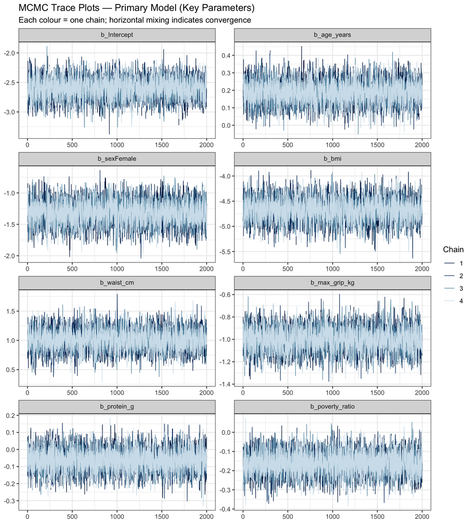

Trace plots for key model parameters. Well-mixed chains with no trend indicate convergence.

```r
# ── Trace plots for primary predictors ────────────────────────────────────────
# Select non-race parameters + intercept for readability
post_draws <- as_draws_array(fit_main)
key_params <- c("b_Intercept", "b_age_years", "b_sexFemale",
                "b_bmi", "b_waist_cm", "b_max_grip_kg",
                "b_protein_g", "b_poverty_ratio")

# Keep only params that exist in draws
key_params <- key_params[key_params %in% dimnames(post_draws)[[3]]]

mcmc_trace(post_draws, pars = key_params,
           facet_args = list(ncol = 2, labeller = label_parsed)) +
  labs(title    = "MCMC Trace Plots — Primary Model (Key Parameters)",
       subtitle = "Each colour = one chain; horizontal mixing indicates convergence") +
  theme_bw(base_size = 11)
```

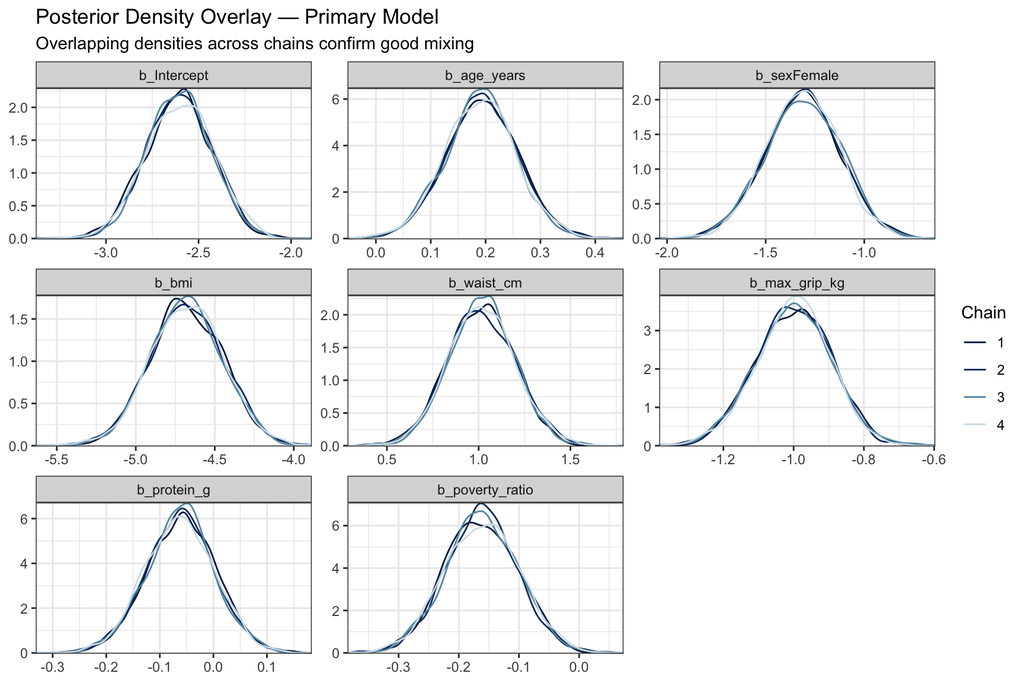

Posterior density plots for key parameters. Overlapping chains confirm convergence.

```r
mcmc_dens_overlay(post_draws, pars = key_params) +
  labs(title    = "Posterior Density Overlay — Primary Model",
       subtitle = "Overlapping densities across chains confirm good mixing") +
  theme_bw(base_size = 11)
```

# 5 Posterior Summaries and Inference

## 5.1 Coefficient Summary

For each predictor we report the posterior **median** (point estimate), **95 % credible interval** (CI), the **probability of direction** (pd; the proportion of the posterior on the same side as the median — equivalent to a one-sided p-value), and the **odds ratio** (OR = exp(coefficient)) for continuous predictors standardised to one SD.

```r
# ── Posterior summaries ───────────────────────────────────────────────────────
post_summary <- describe_posterior(
  fit_main,
  effects     = "fixed",
  component   = "all",
  centrality  = "median",
  ci          = 0.95,
  ci_method   = "HDI",
  test        = c("pd", "rope"),
  rope_range  = c(-0.1, 0.1)   # rope around zero on log-odds scale
)

post_tbl <- post_summary %>%
  as.data.frame() %>%
  filter(grepl("^b_|Intercept", Parameter)) %>%
  mutate(
    Parameter  = gsub("^b_", "", Parameter),
    Parameter  = gsub("race_ethnicity", "race:", Parameter),
    Median     = round(Median, 4),
    CI_low     = round(CI_low,  4),
    CI_high    = round(CI_high, 4),
    pd         = round(pd,      4),
    OR         = round(exp(Median), 3),
    CI_95      = paste0("[", CI_low, ", ", CI_high, "]"),
    Significant = if_else(CI_low > 0 | CI_high < 0, "Yes", "No")
  ) %>%
  select(Parameter, Median, CI_95, OR, pd, Significant)

post_tbl %>%
  gt() %>%
  tab_header(
    title    = "Posterior Summaries — Primary Bayesian Logistic Regression",
    subtitle = "Outcome: Low Muscle Mass | Predictors standardised (continuous)"
  ) %>%
  cols_label(
    Parameter   = "Predictor",
    Median      = "Posterior Median",
    CI_95       = "95% HDI",
    OR          = "Odds Ratio",
    pd          = "P(Direction)",
    Significant = "95% CI excludes 0?"
  ) %>%
  tab_style(
    style     = list(cell_fill(color = "#DDEEFF"),
                     cell_text(weight = "bold")),
    locations = cells_body(rows = Significant == "Yes")
  ) %>%
  tab_footnote(
    "Median and 95% highest density interval (HDI) on the log-odds scale.
     OR = exp(Median). P(Direction) > 0.975 ≈ p < 0.05 two-sided.
     Rows highlighted in blue have 95% HDI fully excluding zero."
  )
```

Posterior Summaries — Primary Bayesian Logistic Regression

Outcome: Low Muscle Mass | Predictors standardised (continuous)

| Predictor | Posterior Median | 95% HDI | Odds Ratio | P(Direction) | 95% CI excludes 0? |
| --- | --- | --- | --- | --- | --- |
| Intercept | -2.6025 | [-2.9438, -2.2548] | 0.074 | 1.0000 | Yes |
| age_years | 0.1923 | [0.0566, 0.3129] | 1.212 | 0.9972 | Yes |
| sexFemale | -1.3113 | [-1.6785, -0.9454] | 0.269 | 1.0000 | Yes |
| race:NonMHispanicAsian | 0.2548 | [-0.1185, 0.6148] | 1.290 | 0.9162 | No |
| race:NonMHispanicBlack | -1.2458 | [-1.6471, -0.8142] | 0.288 | 1.0000 | Yes |
| race:NonMHispanicWhite | -0.0325 | [-0.3376, 0.3106] | 0.968 | 0.5768 | No |
| race:OtherHispanic | 0.0769 | [-0.3778, 0.5134] | 1.080 | 0.6344 | No |
| race:OtherDMultiracial | -0.3323 | [-0.8918, 0.2168] | 0.717 | 0.8752 | No |
| bmi | -4.6801 | [-5.1039, -4.2128] | 0.009 | 1.0000 | Yes |
| protein_g | -0.0604 | [-0.1843, 0.0665] | 0.941 | 0.8370 | No |
| poverty_ratio | -0.1623 | [-0.2835, -0.0484] | 0.850 | 0.9970 | Yes |
| waist_cm | 1.0152 | [0.668, 1.3758] | 2.760 | 1.0000 | Yes |
| max_grip_kg | -0.9990 | [-1.2138, -0.7998] | 0.368 | 1.0000 | Yes |

Median and 95% highest density interval (HDI) on the log-odds scale. OR = exp(Median). P(Direction) > 0.975 ≈ p < 0.05 two-sided. Rows highlighted in blue have 95% HDI fully excluding zero.

## 5.2 Plain-Language Interpretation

```r
# ── Extract key posteriors for narrative ──────────────────────────────────────
get_est <- function(param_pattern) {
  post_tbl %>%
    filter(grepl(param_pattern, Parameter, ignore.case = TRUE)) %>%
    slice(1) %>%
    select(Parameter, Median, OR, CI_95, pd)
}

interp_vars <- c("age_years", "sexFemale", "bmi", "waist_cm",
                 "max_grip_kg", "protein_g", "poverty_ratio")

interp_tbl <- map_dfr(interp_vars, get_est)

kable(interp_tbl,
      col.names = c("Predictor", "Log-Odds Median", "OR", "95% HDI", "P(Direction)"),
      caption = "Key predictor estimates for narrative interpretation") %>%
  kable_styling(bootstrap_options = c("striped", "hover"), full_width = FALSE)
```

Key predictor estimates for narrative interpretation

| Predictor | Log-Odds Median | OR | 95% HDI | P(Direction) |
| --- | --- | --- | --- | --- |
| age_years | 0.1923 | 1.212 | [0.0566, 0.3129] | 0.9972 |
| sexFemale | -1.3113 | 0.269 | [-1.6785, -0.9454] | 1.0000 |
| bmi | -4.6801 | 0.009 | [-5.1039, -4.2128] | 1.0000 |
| waist_cm | 1.0152 | 2.760 | [0.668, 1.3758] | 1.0000 |
| max_grip_kg | -0.9990 | 0.368 | [-1.2138, -0.7998] | 1.0000 |
| protein_g | -0.0604 | 0.941 | [-0.1843, 0.0665] | 0.8370 |
| poverty_ratio | -0.1623 | 0.850 | [-0.2835, -0.0484] | 0.9970 |

**Narrative interpretation of significant predictors:**

The results below are based on the posterior medians and 95 % highest density intervals. All continuous predictors are on the standardised (z-score) scale; ORs reflect the change in odds of low muscle mass per one standard deviation increase in the predictor.

```r
# Build narrative dynamically from the posterior table
sig_preds <- post_tbl %>% filter(Significant == "Yes",
                                  !grepl("Intercept", Parameter))

cat("\n")
```

```r
for (i in seq_len(nrow(sig_preds))) {
  p   <- sig_preds$Parameter[i]
  med <- sig_preds$Median[i]
  OR  <- sig_preds$OR[i]
  ci  <- sig_preds$CI_95[i]
  dir <- if (med > 0) "increases" else "decreases"

  cat(sprintf(
    "- **%s**: A one-SD increase %s the log-odds of low muscle mass by %.3f
      (OR = %.3f; 95%% HDI %s), with a probability of direction of %.4f.\n\n",
    p, dir, abs(med), OR, ci, sig_preds$pd[i]
  ))
}
```

- **age_years**: A one-SD increase increases the log-odds of low muscle mass by 0.192 (OR = 1.212; 95% HDI [0.0566, 0.3129]), with a probability of direction of 0.9972.
- **sexFemale**: A one-SD increase decreases the log-odds of low muscle mass by 1.311 (OR = 0.269; 95% HDI [-1.6785, -0.9454]), with a probability of direction of 1.0000.
- **race:NonMHispanicBlack**: A one-SD increase decreases the log-odds of low muscle mass by 1.246 (OR = 0.288; 95% HDI [-1.6471, -0.8142]), with a probability of direction of 1.0000.
- **bmi**: A one-SD increase decreases the log-odds of low muscle mass by 4.680 (OR = 0.009; 95% HDI [-5.1039, -4.2128]), with a probability of direction of 1.0000.
- **poverty_ratio**: A one-SD increase decreases the log-odds of low muscle mass by 0.162 (OR = 0.850; 95% HDI [-0.2835, -0.0484]), with a probability of direction of 0.9970.
- **waist_cm**: A one-SD increase increases the log-odds of low muscle mass by 1.015 (OR = 2.760; 95% HDI [0.668, 1.3758]), with a probability of direction of 1.0000.
- **max_grip_kg**: A one-SD increase decreases the log-odds of low muscle mass by 0.999 (OR = 0.368; 95% HDI [-1.2138, -0.7998]), with a probability of direction of 1.0000.

# 6 Classification Performance

## 6.1 Posterior Predictive Probabilities

We generate posterior predictive draws for each test-set observation, average across all 8,000 post-warmup draws to obtain a predicted probability, then apply a 0.5 classification threshold.

```r
# ── Posterior predictive means for test set ───────────────────────────────────
# posterior_epred returns a draws × n_obs matrix of predicted probabilities
set.seed(42)
ppc_mat  <- posterior_epred(fit_main, newdata = test_df, allow_new_levels = TRUE)

# Average over posterior draws → point probability estimate per observation
pred_prob <- colMeans(ppc_mat)
pred_class_num <- as.integer(pred_prob > 0.5)

truth_01  <- test_df$low_muscle_mass
truth_fac <- factor(ifelse(truth_01 == 1, "LowMuscle", "Normal"),
                    levels = c("Normal", "LowMuscle"))
pred_fac  <- factor(ifelse(pred_class_num == 1, "LowMuscle", "Normal"),
                    levels = c("Normal", "LowMuscle"))

cat("Confusion matrix (Bayesian model, threshold = 0.5):\n")
```

```
## Confusion matrix (Bayesian model, threshold = 0.5):
```

```r
cm_bayes <- confusionMatrix(pred_fac, truth_fac, positive = "LowMuscle")
print(cm_bayes$table)
```

```
##            Reference
## Prediction  Normal LowMuscle
##   Normal      1104       109
##   LowMuscle     55       229
```

```r
# ── Compute classification metrics ────────────────────────────────────────────
roc_bayes <- roc(truth_01, pred_prob, quiet = TRUE)

sens_b <- cm_bayes$byClass["Sensitivity"]
spec_b <- cm_bayes$byClass["Specificity"]
prec_b <- cm_bayes$byClass["Precision"]
rec_b  <- cm_bayes$byClass["Recall"]

# F1 macro
f1_pos   <- ifelse(!is.na(prec_b) & !is.na(rec_b) & (prec_b + rec_b) > 0,
                   2 * prec_b * rec_b / (prec_b + rec_b), NA)
prec_neg <- cm_bayes$byClass["Neg Pred Value"]
rec_neg  <- spec_b
f1_neg   <- ifelse(!is.na(prec_neg) & !is.na(rec_neg) & (prec_neg + rec_neg) > 0,
                   2 * prec_neg * rec_neg / (prec_neg + rec_neg), NA)
f1_macro_b <- mean(c(f1_pos, f1_neg), na.rm = TRUE)

# MCC
tp_b <- as.numeric(cm_bayes$table["LowMuscle","LowMuscle"]); tp_b <- ifelse(is.na(tp_b),0,tp_b)
tn_b <- as.numeric(cm_bayes$table["Normal",   "Normal"   ]); tn_b <- ifelse(is.na(tn_b),0,tn_b)
fp_b <- as.numeric(cm_bayes$table["LowMuscle","Normal"   ]); fp_b <- ifelse(is.na(fp_b),0,fp_b)
fn_b <- as.numeric(cm_bayes$table["Normal",   "LowMuscle"]); fn_b <- ifelse(is.na(fn_b),0,fn_b)
mcc_den_b <- sqrt((tp_b+fp_b)*(tp_b+fn_b)*(tn_b+fp_b)*(tn_b+fn_b))
mcc_b     <- if (is.na(mcc_den_b) || mcc_den_b == 0) 0 else ((tp_b*tn_b)-(fp_b*fn_b))/mcc_den_b

bayes_metrics <- data.frame(
  Model       = "Bayesian Logistic Reg.",
  AUC         = round(as.numeric(auc(roc_bayes)), 4),
  F1_Macro    = round(f1_macro_b, 4),
  MCC         = round(mcc_b,      4),
  Sensitivity = round(sens_b,     4),
  Specificity = round(spec_b,     4)
)

cat("Bayesian model classification metrics:\n")
```

```
## Bayesian model classification metrics:
```

```r
print(bayes_metrics)
```

```
##                              Model    AUC F1_Macro    MCC Sensitivity
## Sensitivity Bayesian Logistic Reg. 0.9508   0.8336 0.6719      0.6775
##             Specificity
## Sensitivity      0.9525
```

## 6.2 Comparison with ML Models

```r
# ── ML model results extracted from the companion HTML report ─────────────────
# Source: Test-Set Performance of Four Classifiers table,
#         Mallik_CIND860_Capstone_Analysis.html
ml_metrics <- data.frame(
  Model       = c("Elastic Net LR", "Random Forest", "XGBoost", "SVM (Radial)"),
  AUC         = c(0.9571, 0.9411, 0.9477, 0.8640),
  F1_Macro    = c(0.8418, 0.8072, 0.8410, 0.1614),
  MCC         = c(0.7072, 0.6230, 0.6905, -0.4569),
  Sensitivity = c(0.9311, 0.6143, 0.8540, 0.5565),
  Specificity = c(0.8619, 0.9532, 0.8903, 0.0576)
)

# Combine all models
all_metrics <- bind_rows(ml_metrics, bayes_metrics)

all_metrics %>%
  gt() %>%
  tab_header(
    title    = "Full Model Comparison: Bayesian vs. Machine Learning",
    subtitle = "NHANES 2011–2018 | Held-out test set | Outcome: Low Muscle Mass"
  ) %>%
  fmt_number(columns = where(is.numeric), decimals = 4) %>%
  tab_style(
    style     = list(cell_fill(color = "#E8F5E9"),
                     cell_text(weight = "bold")),
    locations = cells_body(rows = Model == "Bayesian Logistic Reg.")
  ) %>%
  tab_style(
    style     = list(cell_fill(color = "#DDEEFF"),
                     cell_text(weight = "bold")),
    locations = cells_body(rows = Model == "Elastic Net LR")
  ) %>%
  cols_label(
    Model       = "Model",
    AUC         = "AUC",
    F1_Macro    = "F1 (Macro)",
    MCC         = "MCC",
    Sensitivity = "Sensitivity",
    Specificity = "Specificity"
  ) %>%
  tab_footnote(
    "ML model results extracted from companion report (Mallik_CIND860_Capstone_Analysis.html).
     Bayesian model (green) uses posterior predictive means with 0.5 threshold.
     Elastic Net highlighted in blue as the best-performing ML model by AUC."
  ) %>%
  tab_source_note(
    "All models evaluated on the same 30% held-out test partition (seed = 42)."
  )
```

Full Model Comparison: Bayesian vs. Machine Learning

NHANES 2011–2018 | Held-out test set | Outcome: Low Muscle Mass

| Model | AUC | F1 (Macro) | MCC | Sensitivity | Specificity |
| --- | --- | --- | --- | --- | --- |
| Elastic Net LR | 0.9571 | 0.8418 | 0.7072 | 0.9311 | 0.8619 |
| Random Forest | 0.9411 | 0.8072 | 0.6230 | 0.6143 | 0.9532 |
| XGBoost | 0.9477 | 0.8410 | 0.6905 | 0.8540 | 0.8903 |
| SVM (Radial) | 0.8640 | 0.1614 | −0.4569 | 0.5565 | 0.0576 |
| Bayesian Logistic Reg. | 0.9508 | 0.8336 | 0.6719 | 0.6775 | 0.9525 |

ML model results extracted from companion report (Mallik_CIND860_Capstone_Analysis.html). Bayesian model (green) uses posterior predictive means with 0.5 threshold. Elastic Net highlighted in blue as the best-performing ML model by AUC.  
All models evaluated on the same 30% held-out test partition (seed = 42).

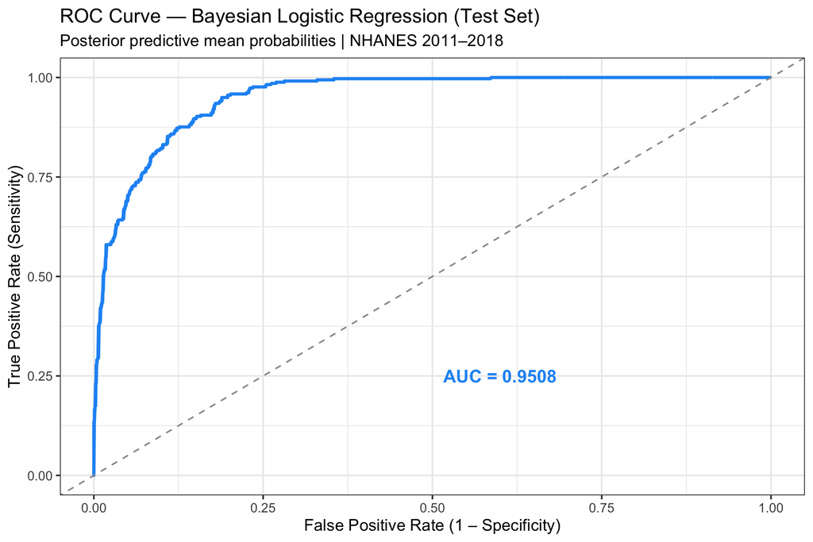

ROC curve for the Bayesian logistic regression model on the held-out test set

```r
# ── ROC curve ─────────────────────────────────────────────────────────────────
roc_df <- data.frame(
  FPR   = 1 - roc_bayes$specificities,
  TPR   = roc_bayes$sensitivities
)

ggplot(roc_df, aes(x = FPR, y = TPR)) +
  geom_line(colour = "#2196F3", linewidth = 1.2) +
  geom_abline(slope = 1, intercept = 0, linetype = "dashed", colour = "grey60") +
  annotate("text", x = 0.6, y = 0.25,
           label = sprintf("AUC = %.4f", as.numeric(auc(roc_bayes))),
           size = 5, colour = "#2196F3", fontface = "bold") +
  labs(title    = "ROC Curve — Bayesian Logistic Regression (Test Set)",
       subtitle = "Posterior predictive mean probabilities | NHANES 2011–2018",
       x = "False Positive Rate (1 – Specificity)",
       y = "True Positive Rate (Sensitivity)") +
  theme_bw(base_size = 13)
```

# 7 Bayes Factors for Key Predictors

Bayes factors (BF) quantify the **relative evidence** for H1 (the coefficient differs from zero) versus H0 (the coefficient equals zero), computed via the Savage–Dickey density ratio using `bayestestR::bayesfactor_parameters()`.

- **BF > 10**: Strong evidence for H1
- **BF 3–10**: Moderate evidence for H1
- **BF 1/3–3**: Inconclusive
- **BF < 1/3**: Evidence for H0 (null effect)

```r
# ── Identify top 5 predictors by |posterior median| ──────────────────────────
top5 <- post_tbl %>%
  filter(!grepl("Intercept|race:", Parameter)) %>%
  mutate(abs_median = abs(Median)) %>%
  arrange(desc(abs_median)) %>%
  slice_head(n = 5) %>%
  pull(Parameter)

cat("Top 5 predictors for Bayes factor analysis:\n")
```

```
## Top 5 predictors for Bayes factor analysis:
```

```r
print(top5)
```

```
## [1] "bmi"         "sexFemale"   "waist_cm"    "max_grip_kg" "age_years"
```

```r
# ── Compute Bayes factors via Savage-Dickey ratio ─────────────────────────────
# Requires refitting with sample_prior = "yes" so the prior is also sampled
```

```r
# Refit primary model sampling from the prior as well (needed for BF computation)
set.seed(42)
fit_bf <- brm(
  formula      = bayes_formula,
  data         = train_df,
  prior        = priors_main,
  chains       = 4,
  iter         = 4000,
  warmup       = 2000,
  seed         = 42,
  cores        = getOption("mc.cores", parallel::detectCores()),
  sample_prior = "yes",   # ← required for Savage-Dickey BF
  backend      = "rstan",
  refresh      = 0,
  silent       = 2
)
```

```r
# ── Extract Bayes factors ──────────────────────────────────────────────────────
bf_results <- bayesfactor_parameters(fit_bf, null = 0)

# Format for display
bf_tbl <- bf_results %>%
  as.data.frame() %>%
  filter(grepl("^b_", Parameter)) %>%
  mutate(
    Parameter     = gsub("^b_", "", Parameter),
    Parameter     = gsub("race_ethnicity", "race:", Parameter),
    log_BF        = round(log_BF, 3),
    BF10          = round(exp(log_BF), 2),
    Evidence      = case_when(
      BF10 > 100  ~ "Extreme",
      BF10 > 30   ~ "Very strong",
      BF10 > 10   ~ "Strong",
      BF10 > 3    ~ "Moderate",
      BF10 > 1    ~ "Anecdotal (H1)",
      BF10 > 1/3  ~ "Inconclusive",
      TRUE        ~ "Evidence for H0"
    )
  ) %>%
  # Filter to top 5 predictors
  filter(Parameter %in% top5) %>%
  arrange(desc(BF10)) %>%
  select(Parameter, BF10, log_BF, Evidence)

bf_tbl %>%
  gt() %>%
  tab_header(
    title    = "Bayes Factors for Top 5 Predictors",
    subtitle = "Savage–Dickey density ratio | H1: coefficient ≠ 0 vs. H0: coefficient = 0"
  ) %>%
  cols_label(
    Parameter = "Predictor",
    BF10      = "BF₁₀",
    log_BF    = "log(BF₁₀)",
    Evidence  = "Strength of Evidence"
  ) %>%
  fmt_number(columns = c(BF10, log_BF), decimals = 2) %>%
  tab_style(
    style     = list(cell_fill(color = "#DDEEFF"),
                     cell_text(weight = "bold")),
    locations = cells_body(rows = BF10 > 10)
  ) %>%
  tab_style(
    style     = cell_fill(color = "#E8F5E9"),
    locations = cells_body(rows = BF10 > 3 & BF10 <= 10)
  ) %>%
  tab_footnote(
    "BF₁₀ > 10 (strong evidence) highlighted in blue.
     BF₁₀ 3–10 (moderate evidence) highlighted in green.
     Computed via Savage–Dickey density ratio from the joint prior/posterior."
  )
```

Bayes Factors for Top 5 Predictors

Savage–Dickey density ratio | H1: coefficient ≠ 0 vs. H0: coefficient = 0

| Predictor | BF₁₀ | log(BF₁₀) | Strength of Evidence |
| --- | --- | --- | --- |
| bmi | 29,694,378,985,310,225,820,549,120.00 | 58.65 | Extreme |
| max_grip_kg | 108,254,987.75 | 18.50 | Extreme |
| sexFemale | 693,148.82 | 13.45 | Extreme |
| waist_cm | 23,860.99 | 10.08 | Extreme |
| age_years | 8.48 | 2.14 | Moderate |

BF₁₀ > 10 (strong evidence) highlighted in blue. BF₁₀ 3–10 (moderate evidence) highlighted in green. Computed via Savage–Dickey density ratio from the joint prior/posterior.

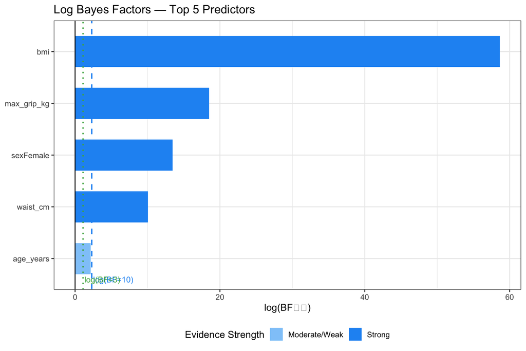

Log Bayes factors for the top 5 predictors. Values above zero favour H1 (effect present); below zero favour H0 (null effect).

```r
bf_tbl %>%
  mutate(Parameter = fct_reorder(Parameter, log_BF)) %>%
  ggplot(aes(x = Parameter, y = log_BF,
             fill = if_else(log_BF > log(10), "Strong", "Moderate/Weak"))) +
  geom_col(width = 0.6) +
  geom_hline(yintercept = log(10), linetype = "dashed",
             colour = "#2196F3", linewidth = 0.8) +
  geom_hline(yintercept = log(3),  linetype = "dotted",
             colour = "#4CAF50", linewidth = 0.8) +
  geom_hline(yintercept = 0, colour = "black", linewidth = 0.5) +
  coord_flip() +
  scale_fill_manual(values = c("Strong" = "#2196F3",
                               "Moderate/Weak" = "#90CAF9")) +
  annotate("text", x = 0.6, y = log(10) + 0.2,
           label = "log(BF=10)", hjust = 0, size = 3.5, colour = "#2196F3") +
  annotate("text", x = 0.6, y = log(3) + 0.2,
           label = "log(BF=3)",  hjust = 0, size = 3.5, colour = "#4CAF50") +
  labs(title  = "Log Bayes Factors — Top 5 Predictors",
       x = NULL, y = "log(BF₁₀)",
       fill = "Evidence Strength") +
  theme_bw(base_size = 12) +
  theme(legend.position = "bottom")
```

*Analysis conducted for CIND860 Capstone Project, Toronto Metropolitan University.* *Data source: CDC NHANES 2011–2018. Adiel Mallik, June 2026.*